# Stat 218 Analytics Project 2 - The Coffee Project

```r
library("here")
library("tidyverse")
library("lubridate")
library("arules")
library("arulesViz")
library("padr")
library("ggplot2")
```

# PART I. ASSOCIATION RULES MINING

## Data Preparation

We begin by preparing our data to be in the proper format for association rules mining. Our main transaction file `dream cafe transactions.txt`, is loaded in as a dataframe so we can do some cleanup, instead of using the file as input directly into the `read.transactions()` function.

We remove the size from the item code since it’s not very relevant, and also add the item names and categories to the dataset from the file `menu items and codes.csv`. This was given as a pdf file, but we also encoded it as a csv for easier use in the analysis.

The final cleaned transaction data now has the following columns, and is written out to `dream cafe transactions_clean.txt`:

- `item_code` - unique Item Code of a Product
- `trans_id` - unique Transaction ID of a transaction (now cleaned up and size removed from beverages)
- `date` - date of when a transaction occurred
- `time` - time of when a transaction occurred
- `qty`- quantity of the item purchased in a given transaction
- `Category` - general product category of a product (e.g. CAKES, ESPRESSO DRINK, etc)
- `Item` - the item name corresponding to the Item Code

```r
raw_trans <- read.delim(file = "dream cafe transactions.txt", sep = "\t")
# We encoded the menu from the pdf file in a csv file for ease of interpretations later on.
menu <- read.csv("menu items and codes.csv")

# Separate into item code and size
raw_trans %>% separate(item_code, into=c("item_code", "size"), sep=" - ") -> raw_trans

# Drop Size Column to get Clean data
clean_trans <- subset(raw_trans, select = -size)
clean_trans <- merge(clean_trans, menu, by.x="item_code", by.y="Item_Code")
# Write out to file
write.csv(clean_trans, "dream cafe transactions_clean.txt", sep="\t", row.names=FALSE, quote=FALSE)

# Display sample cleaned data
clean_trans %>% arrange(trans_id) %>% head(10)
```

|  | item_code | trans_id | date | time | qty | ï..Category | Item |
| --- | --- | --- | --- | --- | --- | --- | --- |
| 1 | CCFRP | 110120180606 | 2018-06-06 | 15:53:00 | 1 | ICE-BLENDED DRINKS (FRAPPE) | Chocolate Cream Frappe |
| 2 | CFRP | 110120180606 | 2018-06-06 | 15:53:00 | 1 | ICE-BLENDED DRINKS (FRAPPE) | Caramel Frappe |
| 3 | CFRP | 110120180613 | 2018-06-13 | 15:52:00 | 1 | ICE-BLENDED DRINKS (FRAPPE) | Caramel Frappe |
| 4 | CCFRP | 110120180620 | 2018-06-20 | 15:38:00 | 1 | ICE-BLENDED DRINKS (FRAPPE) | Chocolate Cream Frappe |
| 5 | EFRP | 110120180620 | 2018-06-20 | 15:38:00 | 1 | ICE-BLENDED DRINKS (FRAPPE) | Espresso Frappe |
| 6 | CBPAN | 110120180627 | 2018-06-27 | 15:23:00 | 1 | BREAD/PASTRIES/SANDWICH | Corned Beef Pandesal |
| 7 | CCFRP | 110120180627 | 2018-06-27 | 15:23:00 | 1 | ICE-BLENDED DRINKS (FRAPPE) | Chocolate Cream Frappe |
| 8 | CFRP | 110220180606 | 2018-06-06 | 15:06:00 | 2 | ICE-BLENDED DRINKS (FRAPPE) | Caramel Frappe |
| 9 | EFRP | 110220180606 | 2018-06-06 | 15:06:00 | 1 | ICE-BLENDED DRINKS (FRAPPE) | Espresso Frappe |
| 10 | CFRP | 110220180613 | 2018-06-13 | 15:14:00 | 1 | ICE-BLENDED DRINKS (FRAPPE) | Caramel Frappe |

We do some initial exploration of our transaction data for the dataset description and EDA.

Let’s see the scope of our transaction dates by getting the min and maximum transaction date:

```r
clean_trans %>%
  mutate(Date = as.POSIXct(date, format = "%Y-%m-%d")) %>%
  group_by(Date) %>%
  select(Date) %>%
  # with_ties = FALSE so no dates are repeated
  slice_max(order_by = Date, n = 1, with_ties = FALSE) -> trans_dates

# Get the earliest and latest transaction dates
# Minnimum Date
head(trans_dates, 1)
```

| Date |
| --- |
| 2018-05-02 |

```r
# Maximum Date
tail(trans_dates, 1)
```

| Date |
| --- |
| 2018-07-30 |

And we can do the same for transaction times, to see the earliest and latest logged transaction times within these dates.

```r
clean_trans %>%
  arrange(time) %>%
  group_by(time) %>%
  select(time) %>%
  slice_max(order_by = time, n = 1, with_ties = FALSE) -> trans_times

# Get the earliest and latest transaction times
# Minimum Transaction Time
head(trans_times, 1)
```

| time |
| --- |
| 07:05:00 |

```r
# Maximum Transaction Time
tail(trans_times, 1)
```

| time |
| --- |
| 22:59:00 |

Since we plan to explore the store transactions over different time periods within the operating hours, we can also group our transactions by hour and see the general trend of traffic in the cafe by hour. Are there any patterns in transactions over the course of the day? Are there certain peak hours? We can use this information to later decide on how we want to group our transactions by time period.

```r
clean_trans %>%
  # Adding an arbitrary date - set all dates to be the same for time comparisons
  mutate(time2 = dmy_hms(paste0("01/01/00 ",time))) %>%
  # Get hour of each timestamp only
  mutate(hour = lubridate::floor_date(time2, "1 hour")) %>%
  group_by(hour) %>%
  summarise(trans_count = n_distinct(trans_id)) -> trans_hourly

trans_hourly
```

| hour | trans_count |
| --- | --- |
| 2000-01-01 07:00:00 | 942 |
| 2000-01-01 08:00:00 | 945 |
| 2000-01-01 09:00:00 | 477 |
| 2000-01-01 10:00:00 | 430 |
| 2000-01-01 11:00:00 | 1478 |
| 2000-01-01 12:00:00 | 1537 |
| 2000-01-01 13:00:00 | 764 |
| 2000-01-01 14:00:00 | 686 |
| 2000-01-01 15:00:00 | 2350 |
| 2000-01-01 16:00:00 | 2256 |

[output cut: 6 more lines]

## Association Rules Mining

### On the entire dataset

We first mine association rules from the entire transaction set - without filtering for time periods.

We use our clean transaction file from earlier as input into the `read_transactions()` function from arules, and identify the transaction and item ID columns in the `cols` argument as `trans_id` and `item_code` respectively.

```r
cafe_trans <- read.transactions(file = "dream cafe transactions_clean.txt", format = "single",
                                   sep = ",", header = T, cols = c(2,1), quote = NULL)

cafe_trans
```

```
## transactions in sparse format with
##  17726 transactions (rows) and
##  45 items (columns)
```

Running the association rules on our data…

```r
coffee_apriori <- apriori(data = cafe_trans,
                          parameter = list(support = 0.01, confidence = 0.4,
                                           minlen = 2, maxlen = 5, originalSupport = F))
```

```
## Apriori
##
## Parameter specification:
##  confidence minval smax arem  aval originalSupport maxtime support minlen
##         0.4    0.1    1 none FALSE           FALSE       5    0.01      2
##  maxlen target  ext
##       5  rules TRUE
##
## Algorithmic control:
##  filter tree heap memopt load sort verbose
##     0.1 TRUE TRUE  FALSE TRUE    2    TRUE
##
## Absolute minimum support count: 177
##
## set item appearances ...[0 item(s)] done [0.00s].
## set transactions ...[45 item(s), 17726 transaction(s)] done [0.00s].
## sorting and recoding items ... [43 item(s)] done [0.00s].
## creating transaction tree ... done [0.02s].
## checking subsets of size 1 2 3 4 done [0.01s].
## writing ... [92 rule(s)] done [0.00s].
## creating S4 object  ... done [0.00s].
```

```
## To reduce overplotting, jitter is added! Use jitter = 0 to prevent jitter.
```

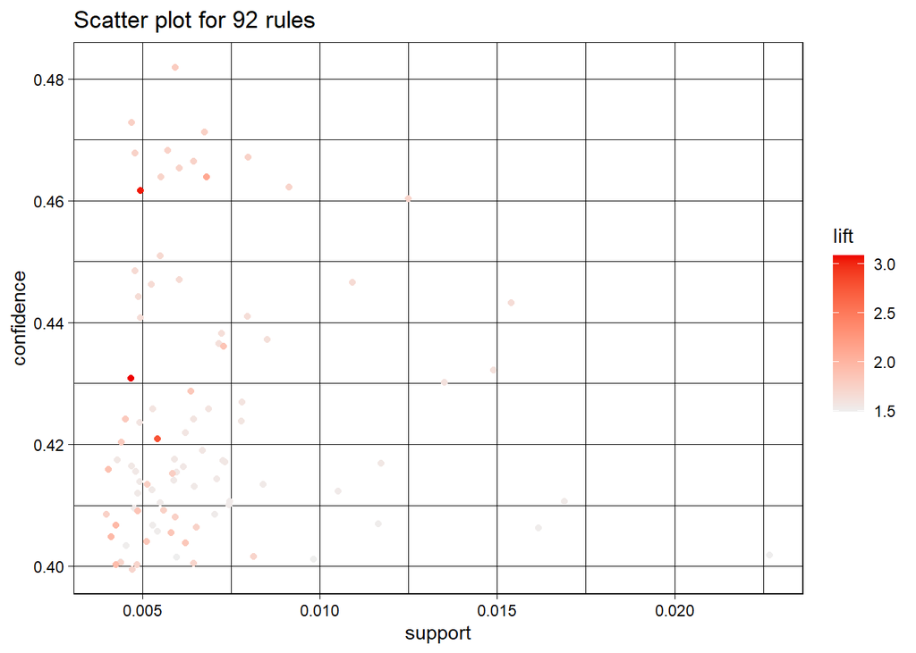

```r
plot(coffee_apriori)
```

Create a rules dataframe.

```r
rules_df <- inspect(coffee_apriori) %>% as.data.frame() %>% dplyr::select(-2)
```

```
##      lhs                        rhs      support     confidence coverage
## [1]  {CCT, LONPAN}           => {CL}     0.004513145 0.4301075  0.01049306
## [2]  {CCT, LONPAN}           => {CA}     0.004851630 0.4623656  0.01049306
## [3]  {CCT, CMAC}             => {CA}     0.005528602 0.4206009  0.01314453
## [4]  {DCCAKE, HGD}           => {VCFRP}  0.004851630 0.4673913  0.01038023
## [5]  {BCCM, VCFRP}           => {ICMAC}  0.006487645 0.4063604  0.01596525
## [6]  {BANPIE, MACC}          => {ICMAC}  0.004174659 0.4088398  0.01021099
## [7]  {MACC, NYCAKE}          => {VCFRP}  0.004851630 0.4236453  0.01145210
## [8]  {CCCAKE, MACC}          => {VCFRP}  0.004625973 0.4480874  0.01032382
## [9]  {DCCAKE, MACC}          => {VCFRP}  0.005246531 0.4133333  0.01269322
## [10] {CSALSW, DCMFRP}        => {WCFRP}  0.005979917 0.4061303  0.01472413
## [11] {BANPIE, CSALSW}        => {WCFRP}  0.005020873 0.4045455  0.01241115
## [12] {BANPIE, CSALSW}        => {VCFRP}  0.005979917 0.4818182  0.01241115
## [13] {CSALSW, NYCAKE}        => {WCFRP}  0.004964459 0.4093023  0.01212908
## [14] {CSALSW, NYCAKE}        => {ICMAC}  0.004851630 0.4000000  0.01212908
```

[output cut: 171 more lines]

```r
rules_df %>% arrange(desc(support))
```

|  | lhs | rhs | support | confidence | coverage | lift | count |
| --- | --- | --- | --- | --- | --- | --- | --- |
| [65] | {DCCAKE, WCFRP} | {VCFRP} | 0.022847794 | 0.4025845 | 0.05675279 | 1.502993 | 405 |
| [63] | {DCCAKE, NYCAKE} | {VCFRP} | 0.016755049 | 0.4113573 | 0.04073113 | 1.535746 | 297 |
| [61] | {BANPIE, WCFRP} | {VCFRP} | 0.016190906 | 0.4059406 | 0.03988491 | 1.515523 | 287 |
| [64] | {CCCAKE, DCCAKE} | {VCFRP} | 0.015401106 | 0.4431818 | 0.03475121 | 1.654558 | 273 |
| [60] | {BANPIE, DCCAKE} | {VCFRP} | 0.014893377 | 0.4320786 | 0.03446914 | 1.613105 | 264 |
| [59] | {BANPIE, CCCAKE} | {VCFRP} | 0.013539434 | 0.4308797 | 0.03142277 | 1.608630 | 240 |
| [58] | {BANPIE, NYCAKE} | {VCFRP} | 0.012636805 | 0.4599589 | 0.02747377 | 1.717193 | 224 |
| [45] | {CYAKSW, WCFRP} | {VCFRP} | 0.011621347 | 0.4063116 | 0.02860205 | 1.516908 | 206 |
| [62] | {CCCAKE, NYCAKE} | {VCFRP} | 0.011564933 | 0.4175153 | 0.02769942 | 1.558735 | 205 |
| [57] | {CPES, DCCAKE} | {VCFRP} | 0.010944375 | 0.4459770 | 0.02454022 | 1.664993 | 194 |

[output cut: 82 more lines]

Filter rules dataframe to get corresponding rules. For brevity when recommending product bundles, we select the top 3 rules according to our criteria.

```r
# Create Menu Data Objects for Recoding
codes <- menu$Item_Code
names <- menu$Item
categories <- menu$ï..Category

# Filter association rules
rules_df %>%
  # High Frequency, Positive Association
  filter(lift > 1) %>%
  # Good Quality Rules First
  arrange(desc(support)) %>%
  # Clean Up Data
  mutate(lhs=gsub("[{}]", "", lhs),
         rhs=gsub("[{}]", "", rhs)) %>%
 separate("lhs", sep=",", into=c("lhs_p1", "lhs_p2", "lhs_p3")) %>%
  # Get just the top 5
  head(10)  -> rules_df_clean

rules_df_clean %>%
  # Recode Item Codes for easier Interpretation
  mutate(lhs_p1 = names[match(trimws(rules_df_clean$lhs_p1, which=c("both")), codes)],
         lhs_p2 = names[match(trimws(rules_df_clean$lhs_p2, which=c("both")), codes)],
         lhs_p3 = names[match(trimws(rules_df_clean$lhs_p3, which=c("both")), codes)],
         rhs = names[match(trimws(rules_df_clean$rhs, which=c("both")), codes)])
```

|  | lhs_p1 | lhs_p2 | lhs_p3 | rhs | support | confidence | coverage | lift | count |
| --- | --- | --- | --- | --- | --- | --- | --- | --- | --- |
| [65] | Dayap Cheesecake | White Chocolate Mocha Frappe | NA | Vanilla Caffe Frappe | 0.02284779 | 0.4025845 | 0.05675279 | 1.502993 | 405 |
| [63] | Dayap Cheesecake | New York Cheesecake | NA | Vanilla Caffe Frappe | 0.01675505 | 0.4113573 | 0.04073113 | 1.535746 | 297 |
| [61] | Banoffee Pie | White Chocolate Mocha Frappe | NA | Vanilla Caffe Frappe | 0.01619091 | 0.4059406 | 0.03988491 | 1.515523 | 287 |
| [64] | Classic Chocolate Cake | Dayap Cheesecake | NA | Vanilla Caffe Frappe | 0.01540111 | 0.4431818 | 0.03475121 | 1.654558 | 273 |
| [60] | Banoffee Pie | Dayap Cheesecake | NA | Vanilla Caffe Frappe | 0.01489338 | 0.4320786 | 0.03446914 | 1.613105 | 264 |
| [59] | Banoffee Pie | Classic Chocolate Cake | NA | Vanilla Caffe Frappe | 0.01353943 | 0.4308797 | 0.03142277 | 1.608630 | 240 |
| [58] | Banoffee Pie | New York Cheesecake | NA | Vanilla Caffe Frappe | 0.01263680 | 0.4599589 | 0.02747377 | 1.717193 | 224 |
| [45] | Chicken Yakitori Sandwich | White Chocolate Mocha Frappe | NA | Vanilla Caffe Frappe | 0.01162135 | 0.4063116 | 0.02860205 | 1.516908 | 206 |
| [62] | Classic Chocolate Cake | New York Cheesecake | NA | Vanilla Caffe Frappe | 0.01156493 | 0.4175153 | 0.02769942 | 1.558735 | 205 |
| [57] | Chicken Pesto Pasta | Dayap Cheesecake | NA | Vanilla Caffe Frappe | 0.01094438 | 0.4459770 | 0.02454022 | 1.664993 | 194 |

We can also examine the item categories to get the general behaviors/patterns across the transaction set.

```r
rules_df_clean %>%
  # Get Item Categories for Interpretations
  mutate(lhs_p1 = categories[match(trimws(rules_df_clean$lhs_p1, which=c("both")), codes)],
         lhs_p2 = categories[match(trimws(rules_df_clean$lhs_p2, which=c("both")), codes)],
         lhs_p3 = categories[match(trimws(rules_df_clean$lhs_p3, which=c("both")), codes)],
         rhs = categories[match(trimws(rules_df_clean$rhs, which=c("both")), codes)])
```

|  | lhs_p1 | lhs_p2 | lhs_p3 | rhs | support | confidence | coverage | lift | count |
| --- | --- | --- | --- | --- | --- | --- | --- | --- | --- |
| [65] | CAKES | ICE-BLENDED DRINKS (FRAPPE) | NA | ICE-BLENDED DRINKS (FRAPPE) | 0.02284779 | 0.4025845 | 0.05675279 | 1.502993 | 405 |
| [63] | CAKES | CAKES | NA | ICE-BLENDED DRINKS (FRAPPE) | 0.01675505 | 0.4113573 | 0.04073113 | 1.535746 | 297 |
| [61] | CAKES | ICE-BLENDED DRINKS (FRAPPE) | NA | ICE-BLENDED DRINKS (FRAPPE) | 0.01619091 | 0.4059406 | 0.03988491 | 1.515523 | 287 |
| [64] | CAKES | CAKES | NA | ICE-BLENDED DRINKS (FRAPPE) | 0.01540111 | 0.4431818 | 0.03475121 | 1.654558 | 273 |
| [60] | CAKES | CAKES | NA | ICE-BLENDED DRINKS (FRAPPE) | 0.01489338 | 0.4320786 | 0.03446914 | 1.613105 | 264 |
| [59] | CAKES | CAKES | NA | ICE-BLENDED DRINKS (FRAPPE) | 0.01353943 | 0.4308797 | 0.03142277 | 1.608630 | 240 |
| [58] | CAKES | CAKES | NA | ICE-BLENDED DRINKS (FRAPPE) | 0.01263680 | 0.4599589 | 0.02747377 | 1.717193 | 224 |
| [45] | BREAD/PASTRIES/SANDWICH | ICE-BLENDED DRINKS (FRAPPE) | NA | ICE-BLENDED DRINKS (FRAPPE) | 0.01162135 | 0.4063116 | 0.02860205 | 1.516908 | 206 |
| [62] | CAKES | CAKES | NA | ICE-BLENDED DRINKS (FRAPPE) | 0.01156493 | 0.4175153 | 0.02769942 | 1.558735 | 205 |
| [57] | PASTA | CAKES | NA | ICE-BLENDED DRINKS (FRAPPE) | 0.01094438 | 0.4459770 | 0.02454022 | 1.664993 | 194 |

### Splitting Data by Time

The stores are open from 7:00AM to 11:00PM. Next, let us explore the associations when we separate our transactions by time of day.

First, let’s visualize the transaction volume hourly from the store, so we can maybe get an idea on how time affects our transactions in Dream Cafe. For this, we use the `trans_hourly` dataframe from earlier, which contains the count of transactions grouped by hour.

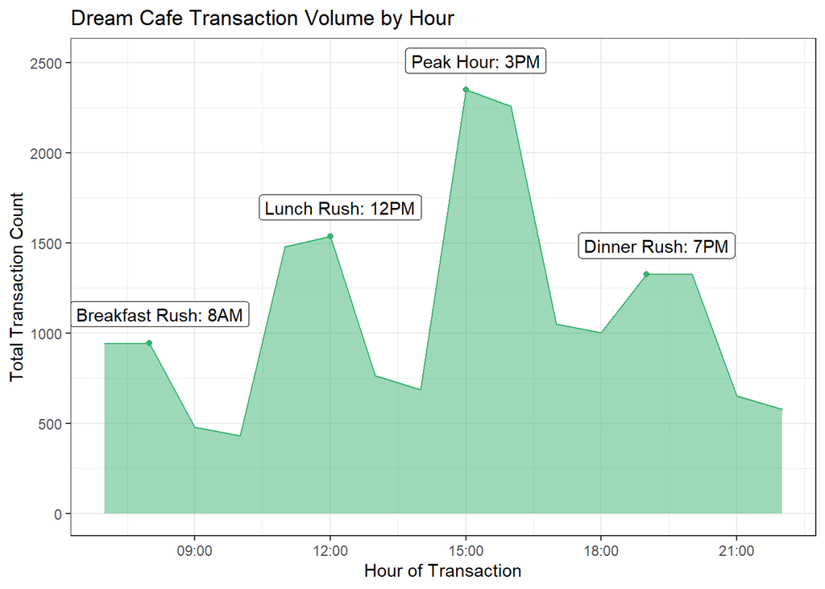

```r
# Create annotations for dataframe
label <- data.frame(
  hour <- c(dmy_hms("01/01/00 15:00:00"),
            dmy_hms("01/01/00 08:00:00"),
            dmy_hms("01/01/00 12:00:00"),
            dmy_hms("01/01/00 19:00:00")),
  trans_count <- c(2350,
                   945,
                   1537,
                   1325),
  labeltext <- c("Peak Hour: 3PM",
                 "Breakfast Rush: 8AM",
                 "Lunch Rush: 12PM",
                 "Dinner Rush: 7PM")
)
# Visualize Transaction Hourly Trend
ggplot(trans_hourly, aes(x=hour, y=trans_count)) +
  geom_area(col="mediumseagreen", fill="mediumseagreen", alpha=0.5) +
  geom_point(data=label, aes(x=hour, y=trans_count), col="mediumseagreen") +
  geom_label(data=label, aes(label=labeltext), nudge_y = 160, nudge_x=800) +
  labs(x = "Hour of Transaction",
       y = "Total Transaction Count",
       title = "Dream Cafe Transaction Volume by Hour") +
  theme_bw()
```

We can see three main peaks in terms of transaction volume throughout the day. Very clearly, Dream Cafe’s peak hour is 3PM - perhaps many customers come here for afternoon snacks. After that, we can see a peak during lunch at 12PM, and one at dinner at 7PM. For breakfast, if you can consider it a peak, there is one at around 8AM. As expected as well, we see low traffic at the start and end of the day.

From these patterns, we are motivated to split up our data later on into four periods based on the peaks: breakfast, lunch, merienda, and dinner. We want each period to contain the peaks we mentioned earlier. These periods are as follows:

- Breakfast Time - 7:00AM - 11:00AM
- Lunch Time - 11:00AM - 2:00PM
- Merienda Time - 2:00PM - 6:00PM
- Dinner Time - 6:00PM - 11:00PM

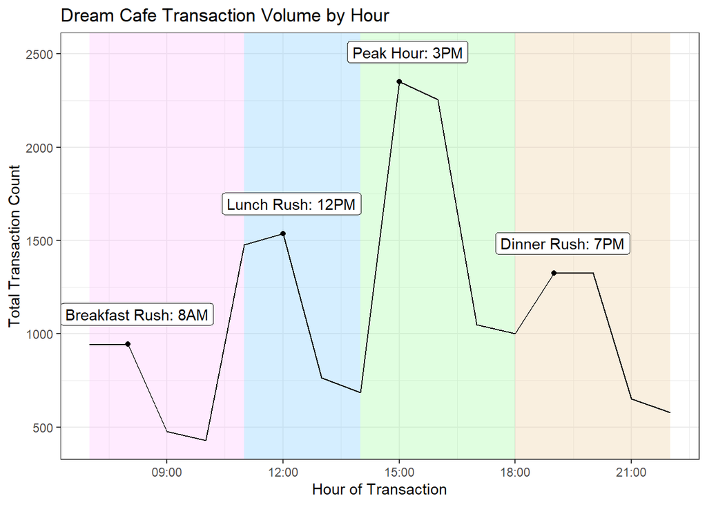

```r
# Visualize Transaction Hourly Trend
ggplot(trans_hourly, aes(x=hour, y=trans_count)) +
  annotate("rect", fill="plum1", alpha=0.3,
           xmin = dmy_hms("01/01/00 07:00:00"),
           xmax = dmy_hms("01/01/00 11:00:00"),
           ymin = -Inf,
           ymax = Inf) +
  annotate("rect", fill="skyblue1", alpha=0.35,
           xmin = dmy_hms("01/01/00 11:00:00"),
           xmax = dmy_hms("01/01/00 14:00:00"),
           ymin = -Inf,
           ymax = Inf) +
  annotate("rect", fill="palegreen", alpha=0.3,
           xmin = dmy_hms("01/01/00 14:00:00"),
           xmax = dmy_hms("01/01/00 18:00:00"),
           ymin = -Inf,
           ymax = Inf) +
  annotate("rect", fill="navajowhite2", alpha=0.34,
           xmin = dmy_hms("01/01/00 18:00:00"),
           xmax = dmy_hms("01/01/00 22:00:00"),
           ymin = -Inf,
           ymax = Inf) +
  geom_line() +
  geom_point(data=label, aes(x=hour, y=trans_count)) +
  geom_label(data=label, aes(label=labeltext),  nudge_y = 160, nudge_x=800) +
  labs(x = "Hour of Transaction",
       y = "Total Transaction Count",
       title = "Dream Cafe Transaction Volume by Hour") +
  theme_bw()
```

We apply these time intervals to our data and create separate datasets for each time period below.

```r
# Helper Function to filter transaction data by a specific lubridate interval
filter_time <- function(interval) {
  clean_trans %>%
  mutate(time2 = format(ymd_hms(paste(date,time)), "%H:%M:%S")) %>%
  # Adding an arbitrary date - set all dates to be the same for time comparisons
  mutate(time2 = dmy_hms(paste0("01/01/00 ",time2))) %>%
  # Filter transactions within the interval only
  filter(time2 %within% interval) %>%
  dplyr::select(-time2) -> filtered

  return(filtered)
}

# Create Lubridate Intervals for each Time Period
breakfast_time <- dmy_hms("1/1/00 07:00:00") %--% dmy_hms("1/1/00 10:59:59")
lunch_time <- dmy_hms("1/1/00 11:00:00") %--% dmy_hms("1/1/00 13:59:59")
merienda_time <- dmy_hms("1/1/00 14:00:00") %--% dmy_hms("1/1/00 17:59:59")
dinner_time <- dmy_hms("1/1/00 18:00:00") %--% dmy_hms("1/1/00 22:59:59")

# Create tibbles/df for each time period
breakfast_trans <- filter_time(breakfast_time)
lunch_trans <- filter_time(lunch_time)
merienda_trans <- filter_time(merienda_time)
dinner_trans <- filter_time(dinner_time)

# Write out to text files as input to read.transactions()
write.csv(breakfast_trans, "breakfast_trans.txt", row.names=FALSE, quote=FALSE)
write.csv(lunch_trans, "lunch_trans.txt", row.names=FALSE, quote=FALSE)
write.csv(merienda_trans, "merienda_trans.txt", row.names=FALSE, quote=FALSE)
write.csv(dinner_trans, "dinner_trans.txt", row.names=FALSE, quote=FALSE)
```

### Breakfast

#### 7:00AM - 11:00AM

We do the same for different time periods on the filtered datasets we prepared earlier, starting with breakfast.

```r
# Show Breakfast Transactions
head(breakfast_trans)
```

|  | item_code | trans_id | date | time | qty | ï..Category | Item |
| --- | --- | --- | --- | --- | --- | --- | --- |
| 1 | BANPIE | 111920180502 | 2018-05-02 | 07:07:00 | 1 | CAKES | Banoffee Pie |
| 2 | BANPIE | 111220180728 | 2018-07-28 | 08:56:00 | 1 | CAKES | Banoffee Pie |
| 3 | BANPIE | 111720180612 | 2018-06-12 | 07:32:00 | 1 | CAKES | Banoffee Pie |
| 4 | BANPIE | 122320180623 | 2018-06-23 | 09:54:00 | 1 | CAKES | Banoffee Pie |
| 5 | BANPIE | 111220180526 | 2018-05-26 | 08:23:00 | 1 | CAKES | Banoffee Pie |
| 6 | BANPIE | 112520180621 | 2018-06-21 | 07:11:00 | 1 | CAKES | Banoffee Pie |

```r
# Read in breakfast Data
breakfast <- read.transactions(file = "breakfast_trans.txt", format = "single",
                               sep = ",", header = T, cols = c(2,1), quote = NULL)
# Get transaction and item count
breakfast
```

```
## transactions in sparse format with
##  2796 transactions (rows) and
##  45 items (columns)
```

```r
# Run Assoc Rules Mining
breakfast_apriori <- apriori(data = breakfast,
                            parameter = list(support = 0.01, confidence = 0.5,
                                             minlen = 2, maxlen = 4, originalSupport = F))
```

```
## Apriori
##
## Parameter specification:
##  confidence minval smax arem  aval originalSupport maxtime support minlen
##         0.5    0.1    1 none FALSE           FALSE       5    0.01      2
##  maxlen target  ext
##       4  rules TRUE
##
## Algorithmic control:
##  filter tree heap memopt load sort verbose
##     0.1 TRUE TRUE  FALSE TRUE    2    TRUE
##
## Absolute minimum support count: 27
##
## set item appearances ...[0 item(s)] done [0.00s].
## set transactions ...[45 item(s), 2796 transaction(s)] done [0.00s].
## sorting and recoding items ... [43 item(s)] done [0.00s].
## creating transaction tree ... done [0.00s].
## checking subsets of size 1 2 3 4
```

```
##  done [0.00s].
## writing ... [191 rule(s)] done [0.00s].
## creating S4 object  ... done [0.00s].
```

```r
# Create Rules Dataframe
bfast_rules_df <- inspect(breakfast_apriori) %>% as.data.frame() %>% dplyr::select(-2)
```

```
##       lhs                       rhs      support     confidence coverage
## [1]   {BBM}                  => {CMAC}   0.025035765 0.5223881  0.04792561
## [2]   {CMAC, HGD}            => {CL}     0.005364807 0.5172414  0.01037196
## [3]   {EFRP, ICA}            => {LONPAN} 0.005364807 0.5357143  0.01001431
## [4]   {EFRP, ICA}            => {CL}     0.005364807 0.5357143  0.01001431
## [5]   {CMAC, DCMFRP}         => {LONPAN} 0.006080114 0.5000000  0.01216023
## [6]   {BC, CMFRP}            => {CA}     0.005007153 0.5000000  0.01001431
## [7]   {BBM, ICL}             => {CMAC}   0.005722461 0.5333333  0.01072961
## [8]   {BBM, ICA}             => {CMAC}   0.007510730 0.5250000  0.01430615
## [9]   {BBM, STPAN}           => {CMAC}   0.007153076 0.6451613  0.01108727
## [10]  {BBM, CCT}             => {CMAC}   0.007510730 0.5833333  0.01287554
## [11]  {BBM, CCT}             => {CA}     0.006795422 0.5277778  0.01287554
## [12]  {BBM, CA}              => {CMAC}   0.008226037 0.5750000  0.01430615
## [13]  {BBM, LONPAN}          => {CMAC}   0.008226037 0.6764706  0.01216023
## [14]  {BBM, CL}              => {CMAC}   0.009298999 0.6190476  0.01502146
```

[output cut: 369 more lines]

```r
head(bfast_rules_df)
```

|  | lhs | rhs | support | confidence | coverage | lift | count |
| --- | --- | --- | --- | --- | --- | --- | --- |
| [1] | {BBM} | {CMAC} | 0.025035765 | 0.5223881 | 0.04792561 | 1.947463 | 70 |
| [2] | {CMAC, HGD} | {CL} | 0.005364807 | 0.5172414 | 0.01037196 | 1.839958 | 15 |
| [3] | {EFRP, ICA} | {LONPAN} | 0.005364807 | 0.5357143 | 0.01001431 | 1.837862 | 15 |
| [4] | {EFRP, ICA} | {CL} | 0.005364807 | 0.5357143 | 0.01001431 | 1.905671 | 15 |
| [5] | {CMAC, DCMFRP} | {LONPAN} | 0.006080114 | 0.5000000 | 0.01216023 | 1.715337 | 17 |
| [6] | {BC, CMFRP} | {CA} | 0.005007153 | 0.5000000 | 0.01001431 | 1.856574 | 14 |

We arrange the rules by support to get the most popular item combinations.

```r
# Arrange Rules DF by support
bfast_rules_df %>% arrange(desc(support))
```

|  | lhs | rhs | support | confidence | coverage | lift | count |
| --- | --- | --- | --- | --- | --- | --- | --- |
| [1] | {BBM} | {CMAC} | 0.025035765 | 0.5223881 | 0.04792561 | 1.947463 | 70 |
| [46] | {CMAC, WCFRP} | {CA} | 0.015379113 | 0.5180723 | 0.02968526 | 1.923679 | 43 |
| [47] | {CA, WCFRP} | {CMAC} | 0.015379113 | 0.5000000 | 0.03075823 | 1.864000 | 43 |
| [49] | {CMOC, ICA} | {CCT} | 0.013948498 | 0.5131579 | 0.02718169 | 2.100717 | 39 |
| [191] | {CCT, CMAC, LONPAN} | {CA} | 0.012517883 | 0.5645161 | 0.02217454 | 2.096132 | 35 |
| [184] | {CMAC, ICA, LONPAN} | {CA} | 0.012517883 | 0.5468750 | 0.02288984 | 2.030627 | 35 |
| [165] | {CA, ICL, LONPAN} | {CL} | 0.012160229 | 0.5573770 | 0.02181688 | 1.982731 | 34 |
| [181] | {CCT, CMAC, ICA} | {CA} | 0.011802575 | 0.5322581 | 0.02217454 | 1.976353 | 33 |
| [182] | {CA, CCT, ICA} | {CMAC} | 0.011802575 | 0.5000000 | 0.02360515 | 1.864000 | 33 |
| [183] | {CCT, ICA, LONPAN} | {CA} | 0.011444921 | 0.5161290 | 0.02217454 | 1.916463 | 32 |

[output cut: 181 more lines]

We then select our best rules. For this, we want our lift greater than 1, and to have as much support as possible, since more frequent item sets will be more profitable.

```r
bfast_rules_df %>%
  filter(lift > 1) %>%
  arrange(desc(support)) %>%
  # Clean Up Data
  mutate(lhs=gsub("[{}]", "", lhs),
        rhs=gsub("[{}]", "", rhs)) %>%
  separate("lhs", sep=",", into=c("lhs_p1", "lhs_p2", "lhs_p3"))  %>%
  # Get top 10 rules, choose best 3 from here
  head(10) -> bfast_rules_final
bfast_rules_final %>%
  #Recode Item Codes for easier Interpretation
  mutate(lhs_p1 = names[match(trimws(bfast_rules_final$lhs_p1, which=c("both")), codes)],
         lhs_p2 = names[match(trimws(bfast_rules_final$lhs_p2, which=c("both")), codes)],
         lhs_p3 = names[match(trimws(bfast_rules_final$lhs_p3, which=c("both")), codes)],
         rhs = names[match(trimws(bfast_rules_final$rhs, which=c("both")), codes)])
```

|  | lhs_p1 | lhs_p2 | lhs_p3 | rhs | support | confidence | coverage | lift | count |
| --- | --- | --- | --- | --- | --- | --- | --- | --- | --- |
| [1] | Blueberry Muffin | NA | NA | Caramel Macchiato | 0.02503577 | 0.5223881 | 0.04792561 | 1.947463 | 70 |
| [46] | Caramel Macchiato | White Chocolate Mocha Frappe | NA | Caffe Americano | 0.01537911 | 0.5180723 | 0.02968526 | 1.923679 | 43 |
| [47] | Caffe Americano | White Chocolate Mocha Frappe | NA | Caramel Macchiato | 0.01537911 | 0.5000000 | 0.03075823 | 1.864000 | 43 |
| [49] | Caffe Mocha | Iced Caffe Americano | NA | Cream Cheese on Toast | 0.01394850 | 0.5131579 | 0.02718169 | 2.100717 | 39 |
| [191] | Cream Cheese on Toast | Caramel Macchiato | Longganisa Pandesal | Caffe Americano | 0.01251788 | 0.5645161 | 0.02217454 | 2.096132 | 35 |
| [184] | Caramel Macchiato | Iced Caffe Americano | Longganisa Pandesal | Caffe Americano | 0.01251788 | 0.5468750 | 0.02288984 | 2.030627 | 35 |
| [165] | Caffe Americano | Iced Caffe Latte | Longganisa Pandesal | Caffe Latte | 0.01216023 | 0.5573770 | 0.02181688 | 1.982731 | 34 |
| [181] | Cream Cheese on Toast | Caramel Macchiato | Iced Caffe Americano | Caffe Americano | 0.01180258 | 0.5322581 | 0.02217454 | 1.976353 | 33 |
| [182] | Caffe Americano | Cream Cheese on Toast | Iced Caffe Americano | Caramel Macchiato | 0.01180258 | 0.5000000 | 0.02360515 | 1.864000 | 33 |
| [183] | Cream Cheese on Toast | Iced Caffe Americano | Longganisa Pandesal | Caffe Americano | 0.01144492 | 0.5161290 | 0.02217454 | 1.916463 | 32 |

We can see that generally, espresso drinks and frappes are quite popular during breakfast time. The blueberry muffin, a typical breakfast food is also present in the most popular combination.

### Lunch

#### 11:00AM - 2:00PM

We do the same to get the ideal product bundles for the lunch transaction dataset.

```r
# Show Lunch Transactions
head(lunch_trans)
```

|  | item_code | trans_id | date | time | qty | ï..Category | Item |
| --- | --- | --- | --- | --- | --- | --- | --- |
| 1 | BANPIE | 131420180602 | 2018-06-02 | 12:38:00 | 1 | CAKES | Banoffee Pie |
| 2 | BANPIE | 132420180506 | 2018-05-06 | 12:13:00 | 1 | CAKES | Banoffee Pie |
| 3 | BANPIE | 136420180525 | 2018-05-25 | 11:14:00 | 1 | CAKES | Banoffee Pie |
| 4 | BANPIE | 132020180710 | 2018-07-10 | 12:31:00 | 1 | CAKES | Banoffee Pie |
| 5 | BANPIE | 133020180713 | 2018-07-13 | 11:05:00 | 1 | CAKES | Banoffee Pie |
| 6 | BANPIE | 132820180705 | 2018-07-05 | 12:45:00 | 1 | CAKES | Banoffee Pie |

```r
# Load in Lunch Data
lunch <- read.transactions(file = "lunch_trans.txt", format = "single",
                                   sep = ",", header = T, cols = c(2,1), quote = NULL)
# Get transaction and item count
lunch
```

```
## transactions in sparse format with
##  3781 transactions (rows) and
##  45 items (columns)
```

```r
# Run Association Rules Mining
lunch_apriori <- apriori(data = lunch,
                          parameter = list(support = 0.01, confidence = 0.5,
                                           minlen = 2, maxlen = 4, originalSupport = F))
```

```
## Apriori
##
## Parameter specification:
##  confidence minval smax arem  aval originalSupport maxtime support minlen
##         0.5    0.1    1 none FALSE           FALSE       5    0.01      2
##  maxlen target  ext
##       4  rules TRUE
##
## Algorithmic control:
##  filter tree heap memopt load sort verbose
##     0.1 TRUE TRUE  FALSE TRUE    2    TRUE
##
## Absolute minimum support count: 37
##
## set item appearances ...[0 item(s)] done [0.00s].
## set transactions ...[45 item(s), 3781 transaction(s)] done [0.00s].
## sorting and recoding items ... [43 item(s)] done [0.00s].
## creating transaction tree ... done [0.00s].
## checking subsets of size 1 2 3 4
```

```
##  done [0.00s].
## writing ... [169 rule(s)] done [0.00s].
## creating S4 object  ... done [0.00s].
```

```r
# Create Rules Dataframe
lunch_rules_df <- inspect(lunch_apriori) %>% as.data.frame() %>% dplyr::select(-2)
```

```
##       lhs                        rhs      support     confidence coverage
## [1]   {CSROLL}                => {VCFRP}  0.050515737 0.5052910  0.09997355
## [2]   {DCCAKE, LONPAN}        => {ICMAC}  0.006083047 0.6052632  0.01005025
## [3]   {CMAC, HCC}             => {VCFRP}  0.005289606 0.5263158  0.01005025
## [4]   {HCC, ICL}              => {VCFRP}  0.005289606 0.5263158  0.01005025
## [5]   {ICL, STPAN}            => {VCFRP}  0.006612007 0.6410256  0.01031473
## [6]   {BBM, WCFRP}            => {VCFRP}  0.006612007 0.5813953  0.01137265
## [7]   {BBM, ICMAC}            => {VCFRP}  0.007405448 0.5000000  0.01481090
## [8]   {CCFRP, CDD}            => {VCFRP}  0.006083047 0.5609756  0.01084369
## [9]   {CDD, ICL}              => {VCFRP}  0.006876488 0.5306122  0.01295953
## [10]  {BCCM, ICMAC}           => {VCFRP}  0.008463369 0.5614035  0.01507538
## [11]  {BANPIE, CINROLL}       => {CA}     0.006612007 0.5952381  0.01110817
## [12]  {BANPIE, CINROLL}       => {VCFRP}  0.005554086 0.5000000  0.01110817
## [13]  {CINROLL, CMAC}         => {CA}     0.006876488 0.5416667  0.01269505
## [14]  {CINROLL, ICL}          => {CA}     0.006347527 0.5454545  0.01163713
```

[output cut: 325 more lines]

```r
head(lunch_rules_df)
```

|  | lhs | rhs | support | confidence | coverage | lift | count |
| --- | --- | --- | --- | --- | --- | --- | --- |
| [1] | {CSROLL} | {VCFRP} | 0.050515737 | 0.5052910 | 0.09997355 | 1.523529 | 191 |
| [2] | {DCCAKE, LONPAN} | {ICMAC} | 0.006083047 | 0.6052632 | 0.01005025 | 2.361713 | 23 |
| [3] | {CMAC, HCC} | {VCFRP} | 0.005289606 | 0.5263158 | 0.01005025 | 1.586922 | 20 |
| [4] | {HCC, ICL} | {VCFRP} | 0.005289606 | 0.5263158 | 0.01005025 | 1.586922 | 20 |
| [5] | {ICL, STPAN} | {VCFRP} | 0.006612007 | 0.6410256 | 0.01031473 | 1.932789 | 25 |
| [6] | {BBM, WCFRP} | {VCFRP} | 0.006612007 | 0.5813953 | 0.01137265 | 1.752995 | 25 |

Sorting the lunch bundle combinations by the support to get the most popular combinations.

```r
most_popular_pair_lunch <- lunch_rules_df %>% arrange(desc(support))
most_popular_pair_lunch
```

|  | lhs | rhs | support | confidence | coverage | lift | count |
| --- | --- | --- | --- | --- | --- | --- | --- |
| [1] | {CSROLL} | {VCFRP} | 0.050515737 | 0.5052910 | 0.09997355 | 1.523529 | 191 |
| [65] | {CSROLL, ICMAC} | {VCFRP} | 0.018778101 | 0.5546875 | 0.03385348 | 1.672467 | 71 |
| [73] | {CPPIE, WCFRP} | {VCFRP} | 0.016397778 | 0.5123967 | 0.03200212 | 1.544954 | 62 |
| [64] | {CSROLL, WCFRP} | {VCFRP} | 0.015339857 | 0.5742574 | 0.02671251 | 1.731473 | 58 |
| [86] | {CMAC, CYAKSW} | {VCFRP} | 0.014017456 | 0.5353535 | 0.02618355 | 1.614172 | 53 |
| [82] | {CBFB, CCCAKE} | {ICMAC} | 0.013488495 | 0.5483871 | 0.02459667 | 2.139785 | 51 |
| [87] | {CCCAKE, NYCAKE} | {ICMAC} | 0.012695054 | 0.5052632 | 0.02512563 | 1.971517 | 48 |
| [63] | {CSROLL, ICL} | {VCFRP} | 0.012166094 | 0.5348837 | 0.02274531 | 1.612755 | 46 |
| [62] | {CA, CSROLL} | {VCFRP} | 0.011901613 | 0.5769231 | 0.02062946 | 1.739510 | 45 |
| [53] | {CAP, WCFRP} | {VCFRP} | 0.011637133 | 0.5176471 | 0.02248083 | 1.560784 | 44 |

[output cut: 159 more lines]

Frequency - a bundle is more profitable if it is bought more often.

The most popular pair for lunch is a classic sausage roll and a vanilla caffe frappe. In terms of the item categories, bread/pastries/sandwiches with ice-blended drinks (frappes) are the most popular choice for lunch. This is a combination that is more on the heavy side which suggests that customers are looking for something filling for lunch.

For the most likely items to be bought together,

```r
most_likely_bundle <- lunch_rules_df %>% arrange(desc(lift))
most_likely_bundle
```

|  | lhs | rhs | support | confidence | coverage | lift | count |
| --- | --- | --- | --- | --- | --- | --- | --- |
| [11] | {BANPIE, CINROLL} | {CA} | 0.006612007 | 0.5952381 | 0.01110817 | 3.309699 | 25 |
| [33] | {CCFRP, MACC} | {CA} | 0.008992330 | 0.5762712 | 0.01560434 | 3.204237 | 34 |
| [35] | {ICL, MACC} | {CA} | 0.009521291 | 0.5538462 | 0.01719122 | 3.079548 | 36 |
| [14] | {CINROLL, ICL} | {CA} | 0.006347527 | 0.5454545 | 0.01163713 | 3.032888 | 24 |
| [36] | {MACC, WCFRP} | {CA} | 0.011372653 | 0.5443038 | 0.02089394 | 3.026489 | 43 |
| [13] | {CINROLL, CMAC} | {CA} | 0.006876488 | 0.5416667 | 0.01269505 | 3.011826 | 26 |
| [96] | {CL, CLAS, ICMAC} | {NYCAKE} | 0.005289606 | 0.5263158 | 0.01005025 | 2.979042 | 20 |
| [132] | {CA, CL, WCFRP} | {NYCAKE} | 0.005289606 | 0.5128205 | 0.01031473 | 2.902656 | 20 |
| [97] | {CL, CLAS, ICMAC} | {ICL} | 0.005554086 | 0.5526316 | 0.01005025 | 2.520507 | 21 |
| [101] | {CBFB, CPES, VCFRP} | {ICL} | 0.005554086 | 0.5526316 | 0.01005025 | 2.520507 | 21 |

[output cut: 159 more lines]

Customers who buy bread/pastries/sandwich and espresso drinks are most likely to buy a cafe americano. This can be an potential add on/upselling opportunity to increase the number of items included in a bundle and thus increase the profits. But, support for these transactions are not that high so more focus will still be given to the items with a higher level of support and a lift that is greater than 1.

Get the best 3 rules from the top 10:

```r
lunch_rules_df %>%
  filter(lift > 1) %>%
  arrange(desc(support)) %>%
  head(10) %>%
  # Clean Up Data
  mutate(lhs=gsub("[{}]", "", lhs),
        rhs=gsub("[{}]", "", rhs)) %>%
  separate("lhs", sep=",", into=c("lhs_p1", "lhs_p2", "lhs_p3"))  %>%
  # Get top 10 rules, choose best 3 from here
  head(10) -> lunch_rules_final
lunch_rules_final %>%
  #Recode Item Codes for easier Interpretation
  mutate(lhs_p1 = names[match(trimws(lunch_rules_final$lhs_p1, which=c("both")), codes)],
         lhs_p2 = names[match(trimws(lunch_rules_final$lhs_p2, which=c("both")), codes)],
         lhs_p3 = names[match(trimws(lunch_rules_final$lhs_p3, which=c("both")), codes)],
         rhs = names[match(trimws(lunch_rules_final$rhs, which=c("both")), codes)])
```

|  | lhs_p1 | lhs_p2 | lhs_p3 | rhs | support | confidence | coverage | lift | count |
| --- | --- | --- | --- | --- | --- | --- | --- | --- | --- |
| [1] | Classic Sausage Roll | NA | NA | Vanilla Caffe Frappe | 0.05051574 | 0.5052910 | 0.09997355 | 1.523529 | 191 |
| [65] | Classic Sausage Roll | Iced Caramel Macchiato | NA | Vanilla Caffe Frappe | 0.01877810 | 0.5546875 | 0.03385348 | 1.672467 | 71 |
| [73] | Chicken Pastel Pie | White Chocolate Mocha Frappe | NA | Vanilla Caffe Frappe | 0.01639778 | 0.5123967 | 0.03200212 | 1.544954 | 62 |
| [64] | Classic Sausage Roll | White Chocolate Mocha Frappe | NA | Vanilla Caffe Frappe | 0.01533986 | 0.5742574 | 0.02671251 | 1.731473 | 58 |
| [86] | Caramel Macchiato | Chicken Yakitori Sandwich | NA | Vanilla Caffe Frappe | 0.01401746 | 0.5353535 | 0.02618355 | 1.614172 | 53 |
| [82] | Cheesy Bacon Flatbread | Classic Chocolate Cake | NA | Iced Caramel Macchiato | 0.01348850 | 0.5483871 | 0.02459667 | 2.139785 | 51 |
| [87] | Classic Chocolate Cake | New York Cheesecake | NA | Iced Caramel Macchiato | 0.01269505 | 0.5052632 | 0.02512563 | 1.971517 | 48 |
| [63] | Classic Sausage Roll | Iced Caffe Latte | NA | Vanilla Caffe Frappe | 0.01216609 | 0.5348837 | 0.02274531 | 1.612755 | 46 |
| [62] | Caffe Americano | Classic Sausage Roll | NA | Vanilla Caffe Frappe | 0.01190161 | 0.5769231 | 0.02062946 | 1.739510 | 45 |
| [53] | Cappuccino | White Chocolate Mocha Frappe | NA | Vanilla Caffe Frappe | 0.01163713 | 0.5176471 | 0.02248083 | 1.560784 | 44 |

### Merienda

#### 2:00PM - 6:00 PM

```r
# Display merienda transactions
head(merienda_trans)
```

|  | item_code | trans_id | date | time | qty | ï..Category | Item |
| --- | --- | --- | --- | --- | --- | --- | --- |
| 1 | BANPIE | 154020180522 | 2018-05-22 | 15:58:00 | 2 | CAKES | Banoffee Pie |
| 2 | BANPIE | 161620180615 | 2018-06-15 | 17:29:00 | 1 | CAKES | Banoffee Pie |
| 3 | BANPIE | 161220180716 | 2018-07-16 | 17:25:00 | 1 | CAKES | Banoffee Pie |
| 4 | BANPIE | 155020180723 | 2018-07-23 | 16:58:00 | 1 | CAKES | Banoffee Pie |
| 5 | BANPIE | 162220180614 | 2018-06-14 | 17:54:00 | 2 | CAKES | Banoffee Pie |
| 6 | BANPIE | 142820180601 | 2018-06-01 | 14:49:00 | 1 | CAKES | Banoffee Pie |

```r
# Read in merienda data
merienda <- read.transactions(file = "merienda_trans.txt", format = "single",
                                   sep = ",", header = T, cols = c(2,1), quote = NULL)
# Get transaction and item count
merienda
```

```
## transactions in sparse format with
##  6342 transactions (rows) and
##  45 items (columns)
```

```r
# Run association rules mining
merienda_apriori <- apriori(data = merienda,
                          parameter = list(support = 0.01, confidence = 0.5,
                                           minlen = 2, maxlen = 4, originalSupport = F))
```

```
## Apriori
##
## Parameter specification:
##  confidence minval smax arem  aval originalSupport maxtime support minlen
##         0.5    0.1    1 none FALSE           FALSE       5    0.01      2
##  maxlen target  ext
##       4  rules TRUE
##
## Algorithmic control:
##  filter tree heap memopt load sort verbose
##     0.1 TRUE TRUE  FALSE TRUE    2    TRUE
##
## Absolute minimum support count: 63
##
## set item appearances ...[0 item(s)] done [0.00s].
## set transactions ...[45 item(s), 6342 transaction(s)] done [0.00s].
## sorting and recoding items ... [43 item(s)] done [0.00s].
## creating transaction tree ... done [0.00s].
## checking subsets of size 1 2 3 4
```

```
##  done [0.00s].
## writing ... [16 rule(s)] done [0.00s].
## creating S4 object  ... done [0.00s].
```

```r
# Create rules dataframe
merienda_rules_df <- inspect(merienda_apriori) %>% as.data.frame() %>% dplyr::select(-2)
```

```
##      lhs                         rhs      support     confidence coverage
## [1]  {CINROLL, ICL}           => {VCFRP}  0.005361085 0.5000000  0.01072217
## [2]  {DCCAKE, HGD}            => {VCFRP}  0.006149480 0.5416667  0.01135289
## [3]  {BANPIE, BCCM}           => {ICMAC}  0.005361085 0.5151515  0.01040681
## [4]  {BANPIE, BCCM}           => {VCFRP}  0.005676443 0.5454545  0.01040681
## [5]  {BANPIE, MACC}           => {ICMAC}  0.005834122 0.5285714  0.01103753
## [6]  {CBFB, DCCAKE}           => {ICMAC}  0.008830022 0.5137615  0.01718701
## [7]  {CBFB, DCCAKE}           => {VCFRP}  0.009303059 0.5412844  0.01718701
## [8]  {CSROLL, DCCAKE}         => {VCFRP}  0.012456638 0.5602837  0.02223273
## [9]  {CCCAKE, CLAS}           => {ICMAC}  0.008199306 0.5200000  0.01576790
## [10] {CSROLL, DCCAKE, ICMAC}  => {VCFRP}  0.005991801 0.5937500  0.01009145
## [11] {CSROLL, ICMAC, VCFRP}   => {DCCAKE} 0.005991801 0.5066667  0.01182592
## [12] {BANPIE, NYCAKE, WCFRP}  => {VCFRP}  0.006307159 0.5333333  0.01182592
## [13] {BANPIE, DCCAKE, ICL}    => {ICMAC}  0.005834122 0.5285714  0.01103753
## [14] {BANPIE, DCCAKE, DCMFRP} => {VCFRP}  0.007568590 0.5393258  0.01403343
```

[output cut: 19 more lines]

```r
head(merienda_rules_df)
```

|  | lhs | rhs | support | confidence | coverage | lift | count |
| --- | --- | --- | --- | --- | --- | --- | --- |
| [1] | {CINROLL, ICL} | {VCFRP} | 0.005361085 | 0.5000000 | 0.01072217 | 1.643005 | 34 |
| [2] | {DCCAKE, HGD} | {VCFRP} | 0.006149480 | 0.5416667 | 0.01135289 | 1.779922 | 39 |
| [3] | {BANPIE, BCCM} | {ICMAC} | 0.005361085 | 0.5151515 | 0.01040681 | 1.768864 | 34 |
| [4] | {BANPIE, BCCM} | {VCFRP} | 0.005676443 | 0.5454545 | 0.01040681 | 1.792369 | 36 |
| [5] | {BANPIE, MACC} | {ICMAC} | 0.005834122 | 0.5285714 | 0.01103753 | 1.814943 | 37 |
| [6] | {CBFB, DCCAKE} | {ICMAC} | 0.008830022 | 0.5137615 | 0.01718701 | 1.764091 | 56 |

Sorting the merienda bundle combinations by the support.

```r
most_popular_pair_merienda <- merienda_rules_df %>% arrange(desc(support))
most_popular_pair_merienda
```

|  | lhs | rhs | support | confidence | coverage | lift | count |
| --- | --- | --- | --- | --- | --- | --- | --- |
| [8] | {CSROLL, DCCAKE} | {VCFRP} | 0.012456638 | 0.5602837 | 0.02223273 | 1.841098 | 79 |
| [7] | {CBFB, DCCAKE} | {VCFRP} | 0.009303059 | 0.5412844 | 0.01718701 | 1.778666 | 59 |
| [16] | {BANPIE, DCCAKE, ICMAC} | {VCFRP} | 0.008987701 | 0.5000000 | 0.01797540 | 1.643005 | 57 |
| [6] | {CBFB, DCCAKE} | {ICMAC} | 0.008830022 | 0.5137615 | 0.01718701 | 1.764091 | 56 |
| [9] | {CCCAKE, CLAS} | {ICMAC} | 0.008199306 | 0.5200000 | 0.01576790 | 1.785512 | 52 |
| [14] | {BANPIE, DCCAKE, DCMFRP} | {VCFRP} | 0.007568590 | 0.5393258 | 0.01403343 | 1.772230 | 48 |
| [15] | {BANPIE, DCCAKE, WCFRP} | {ICMAC} | 0.006937874 | 0.5000000 | 0.01387575 | 1.716838 | 44 |
| [12] | {BANPIE, NYCAKE, WCFRP} | {VCFRP} | 0.006307159 | 0.5333333 | 0.01182592 | 1.752539 | 40 |
| [2] | {DCCAKE, HGD} | {VCFRP} | 0.006149480 | 0.5416667 | 0.01135289 | 1.779922 | 39 |
| [11] | {CSROLL, ICMAC, VCFRP} | {DCCAKE} | 0.005991801 | 0.5066667 | 0.01182592 | 2.053214 | 38 |

[output cut: 6 more lines]

Show our top rules by support and with item names:

```r
merienda_rules_df %>%
  filter(lift > 1) %>%
  arrange(desc(support)) %>%
  head(10) %>%
  # Clean Up Data
  mutate(lhs=gsub("[{}]", "", lhs),
        rhs=gsub("[{}]", "", rhs)) %>%
  separate("lhs", sep=",", into=c("lhs_p1", "lhs_p2", "lhs_p3"))  %>%
  # Get top 10 rules, choose best 3 from here
  head(10) -> merienda_rules_final
merienda_rules_final %>%
  #Recode Item Codes for easier Interpretation
  mutate(lhs_p1 = names[match(trimws(merienda_rules_final$lhs_p1, which=c("both")), codes)],
         lhs_p2 = names[match(trimws(merienda_rules_final$lhs_p2, which=c("both")), codes)],
         lhs_p3 = names[match(trimws(merienda_rules_final$lhs_p3, which=c("both")), codes)],
         rhs = names[match(trimws(merienda_rules_final$rhs, which=c("both")), codes)])
```

|  | lhs_p1 | lhs_p2 | lhs_p3 | rhs | support | confidence | coverage | lift | count |
| --- | --- | --- | --- | --- | --- | --- | --- | --- | --- |
| [8] | Classic Sausage Roll | Dayap Cheesecake | NA | Vanilla Caffe Frappe | 0.012456638 | 0.5602837 | 0.02223273 | 1.841098 | 79 |
| [7] | Cheesy Bacon Flatbread | Dayap Cheesecake | NA | Vanilla Caffe Frappe | 0.009303059 | 0.5412844 | 0.01718701 | 1.778666 | 59 |
| [16] | Banoffee Pie | Dayap Cheesecake | Iced Caramel Macchiato | Vanilla Caffe Frappe | 0.008987701 | 0.5000000 | 0.01797540 | 1.643005 | 57 |
| [6] | Cheesy Bacon Flatbread | Dayap Cheesecake | NA | Iced Caramel Macchiato | 0.008830022 | 0.5137615 | 0.01718701 | 1.764091 | 56 |
| [9] | Classic Chocolate Cake | Classic Lasagna | NA | Iced Caramel Macchiato | 0.008199306 | 0.5200000 | 0.01576790 | 1.785512 | 52 |
| [14] | Banoffee Pie | Dayap Cheesecake | Dark Chocolate Mocha Frappe | Vanilla Caffe Frappe | 0.007568590 | 0.5393258 | 0.01403343 | 1.772230 | 48 |
| [15] | Banoffee Pie | Dayap Cheesecake | White Chocolate Mocha Frappe | Iced Caramel Macchiato | 0.006937874 | 0.5000000 | 0.01387575 | 1.716838 | 44 |
| [12] | Banoffee Pie | New York Cheesecake | White Chocolate Mocha Frappe | Vanilla Caffe Frappe | 0.006307159 | 0.5333333 | 0.01182592 | 1.752539 | 40 |
| [2] | Dayap Cheesecake | Honey Glazed Doughnut | NA | Vanilla Caffe Frappe | 0.006149480 | 0.5416667 | 0.01135289 | 1.779922 | 39 |
| [11] | Classic Sausage Roll | Iced Caramel Macchiato | Vanilla Caffe Frappe | Dayap Cheesecake | 0.005991801 | 0.5066667 | 0.01182592 | 2.053214 | 38 |

### Dinner

Finally, we mine association rules for dinner-related transactions.

```r
# Display Dinner Data
head(dinner_trans)
```

|  | item_code | trans_id | date | time | qty | ï..Category | Item |
| --- | --- | --- | --- | --- | --- | --- | --- |
| 1 | BANPIE | 172520180513 | 2018-05-13 | 20:17:00 | 1 | CAKES | Banoffee Pie |
| 2 | BANPIE | 182920180506 | 2018-05-06 | 22:19:00 | 1 | CAKES | Banoffee Pie |
| 3 | BANPIE | 174420180713 | 2018-07-13 | 20:57:00 | 1 | CAKES | Banoffee Pie |
| 4 | BANPIE | 181720180520 | 2018-05-20 | 21:43:00 | 1 | CAKES | Banoffee Pie |
| 5 | BANPIE | 181120180612 | 2018-06-12 | 21:34:00 | 1 | CAKES | Banoffee Pie |
| 6 | BANPIE | 172920180509 | 2018-05-09 | 19:45:00 | 1 | CAKES | Banoffee Pie |

```r
# Read in dinner data transactions
dinner <- read.transactions(file = "dinner_trans.txt", format = "single",
                                   sep = ",", header = T, cols = c(2,1), quote = NULL)
# Get transaction and item count
dinner
```

```
## transactions in sparse format with
##  4884 transactions (rows) and
##  45 items (columns)
```

```r
# Run Association Rules Mining
dinner_apriori <- apriori(data = dinner,
                          parameter = list(support = 0.01, confidence = 0.4,
                                           minlen = 2, maxlen = 4, originalSupport = F))
```

```
## Apriori
##
## Parameter specification:
##  confidence minval smax arem  aval originalSupport maxtime support minlen
##         0.4    0.1    1 none FALSE           FALSE       5    0.01      2
##  maxlen target  ext
##       4  rules TRUE
##
## Algorithmic control:
##  filter tree heap memopt load sort verbose
##     0.1 TRUE TRUE  FALSE TRUE    2    TRUE
##
## Absolute minimum support count: 48
##
## set item appearances ...[0 item(s)] done [0.00s].
## set transactions ...[45 item(s), 4884 transaction(s)] done [0.00s].
## sorting and recoding items ... [43 item(s)] done [0.00s].
## creating transaction tree ... done [0.00s].
## checking subsets of size 1 2 3 4
```

```
##  done [0.00s].
## writing ... [425 rule(s)] done [0.00s].
## creating S4 object  ... done [0.00s].
```

```r
# Create Rules Dataframe
dinner_rules_df <- inspect(dinner_apriori) %>% as.data.frame() %>% dplyr::select(-2)
```

```
##       lhs                         rhs      support     confidence coverage
## [1]   {CA, HGD}                => {DCCAKE} 0.004504505 0.4150943  0.01085176
## [2]   {HGD, NYCAKE}            => {WCFRP}  0.004709255 0.4181818  0.01126126
## [3]   {CEN, CMAC}              => {DCCAKE} 0.004914005 0.4363636  0.01126126
## [4]   {CEN, DCMFRP}            => {WCFRP}  0.005118755 0.4629630  0.01105651
## [5]   {BANPIE, CEN}            => {CA}     0.004709255 0.4035088  0.01167076
## [6]   {CEN, ICL}               => {WCFRP}  0.005118755 0.4237288  0.01208026
## [7]   {CCCAKE, CDD}            => {VCFRP}  0.004914005 0.4137931  0.01187551
## [8]   {BCCM, CAP}              => {MCFRP}  0.004504505 0.4074074  0.01105651
## [9]   {BANPIE, BCCM}           => {ICMAC}  0.005528256 0.4029851  0.01371826
## [10]  {BCCM, CCCAKE}           => {ICMAC}  0.005733006 0.4117647  0.01392301
## [11]  {BCCM, DCCAKE}           => {ICMAC}  0.005528256 0.4153846  0.01330876
## [12]  {CCCAKE, MACC}           => {VCFRP}  0.005528256 0.4426230  0.01248976
## [13]  {DCCAKE, MACC}           => {VCFRP}  0.005528256 0.4090909  0.01351351
## [14]  {CMAC, CMFRP}            => {DCCAKE} 0.004709255 0.4509804  0.01044226
```

[output cut: 837 more lines]

```r
head(dinner_rules_df)
```

|  | lhs | rhs | support | confidence | coverage | lift | count |
| --- | --- | --- | --- | --- | --- | --- | --- |
| [1] | {CA, HGD} | {DCCAKE} | 0.004504505 | 0.4150943 | 0.01085176 | 1.656308 | 22 |
| [2] | {HGD, NYCAKE} | {WCFRP} | 0.004709255 | 0.4181818 | 0.01126126 | 1.870330 | 23 |
| [3] | {CEN, CMAC} | {DCCAKE} | 0.004914005 | 0.4363636 | 0.01126126 | 1.741176 | 24 |
| [4] | {CEN, DCMFRP} | {WCFRP} | 0.005118755 | 0.4629630 | 0.01105651 | 2.070615 | 25 |
| [5] | {BANPIE, CEN} | {CA} | 0.004709255 | 0.4035088 | 0.01167076 | 2.089859 | 23 |
| [6] | {CEN, ICL} | {WCFRP} | 0.005118755 | 0.4237288 | 0.01208026 | 1.895139 | 25 |

Sorting the dinner bundle combinations by the support:

```r
most_popular_pair_dinner <- dinner_rules_df %>% arrange(desc(support))
most_popular_pair_dinner
```

|  | lhs | rhs | support | confidence | coverage | lift | count |
| --- | --- | --- | --- | --- | --- | --- | --- |
| [97] | {CCCAKE, DCCAKE} | {VCFRP} | 0.019451269 | 0.4042553 | 0.04811630 | 1.453890 | 95 |
| [96] | {BANPIE, CCCAKE} | {VCFRP} | 0.018632269 | 0.4062500 | 0.04586405 | 1.461064 | 91 |
| [94] | {CL, VCFRP} | {DCCAKE} | 0.016994267 | 0.4029126 | 0.04217854 | 1.607700 | 83 |
| [95] | {BANPIE, NYCAKE} | {VCFRP} | 0.016994267 | 0.4170854 | 0.04074529 | 1.500033 | 83 |
| [91] | {CPES, DCCAKE} | {VCFRP} | 0.014946765 | 0.4219653 | 0.03542179 | 1.517584 | 73 |
| [93] | {CAP, DCMFRP} | {CCCAKE} | 0.013513514 | 0.4099379 | 0.03296478 | 1.848695 | 66 |
| [69] | {CYAKSW, WCFRP} | {VCFRP} | 0.011670762 | 0.4318182 | 0.02702703 | 1.553019 | 57 |
| [92] | {CAP, CMAC} | {CCCAKE} | 0.011056511 | 0.4000000 | 0.02764128 | 1.803878 | 54 |
| [78] | {CLAS, DCCAKE} | {WCFRP} | 0.011056511 | 0.4285714 | 0.02579853 | 1.916797 | 54 |
| [87] | {CBFB, CCCAKE} | {VCFRP} | 0.010647011 | 0.4031008 | 0.02641278 | 1.449738 | 52 |

[output cut: 415 more lines]

Similar to lunch, when arranged by support, vanilla caffe frappe is the top RHS drink of choice for dinner transactions.

Customers in 3 out of the top 5 most popular dinner pair transactions ordered DCCAKE (Dayap Cheesecake) which is one of the cafe’s specialty items.

The most popular dinner items are cakes (Dayap Cheesecake, Banoffee Pie, Classic Chocolate cake) which suggests that people have a more filling dinner elsewhere then they go to the cafe for their specialty cakes/desserts. This is also supported by the top choice of Vanilla Frappe for dinner.

Thus, promoting cakes and vanilla frappes for dinner time might be more profitable since this is what the customers are looking for.

For the most likely items to be bought together,

```r
most_likely_bundle <- dinner_rules_df %>% arrange(desc(lift))
most_likely_bundle
```

|  | lhs | rhs | support | confidence | coverage | lift | count |
| --- | --- | --- | --- | --- | --- | --- | --- |
| [30] | {CMOC, DCMFRP} | {CMAC} | 0.005528256 | 0.4655172 | 0.01187551 | 2.911122 | 27 |
| [327] | {CA, ICMAC, WCFRP} | {DCMFRP} | 0.006961507 | 0.5312500 | 0.01310401 | 2.820245 | 34 |
| [347] | {BANPIE, CCCAKE, WCFRP} | {DCMFRP} | 0.007166257 | 0.5223881 | 0.01371826 | 2.773199 | 35 |
| [237] | {CA, CMAC, VCFRP} | {DCMFRP} | 0.005733006 | 0.5090909 | 0.01126126 | 2.702609 | 28 |
| [147] | {CAP, DCMFRP, VCFRP} | {CCCAKE} | 0.006347256 | 0.5740741 | 0.01105651 | 2.588899 | 31 |
| [239] | {DCMFRP, ICL, ICMAC} | {CMAC} | 0.004095004 | 0.4081633 | 0.01003276 | 2.552458 | 20 |
| [330] | {CA, ICMAC, VCFRP} | {DCMFRP} | 0.005733006 | 0.4745763 | 0.01208026 | 2.519381 | 28 |
| [317] | {BANPIE, CA, WCFRP} | {DCMFRP} | 0.006756757 | 0.4714286 | 0.01433251 | 2.502671 | 33 |
| [321] | {BANPIE, CA, CCCAKE} | {DCMFRP} | 0.006552007 | 0.4637681 | 0.01412776 | 2.462004 | 32 |
| [112] | {CA, CPES, WCFRP} | {DCMFRP} | 0.005118755 | 0.4629630 | 0.01105651 | 2.457729 | 25 |

[output cut: 415 more lines]

If we want to increase the item count in a transaction, we consider the confidence levels because a high confidence means that if the customer bought the LHS, they’re more likely to buy the RHS thus potentially increasing the profitability.

Sorting by the confidence levels,

```r
most_confident_bundle <- dinner_rules_df %>% arrange(desc(confidence))
most_confident_bundle
```

|  | lhs | rhs | support | confidence | coverage | lift | count |
| --- | --- | --- | --- | --- | --- | --- | --- |
| [147] | {CAP, DCMFRP, VCFRP} | {CCCAKE} | 0.006347256 | 0.5740741 | 0.01105651 | 2.588899 | 31 |
| [272] | {CMAC, ICMAC, NYCAKE} | {DCCAKE} | 0.006347256 | 0.5438596 | 0.01167076 | 2.170107 | 31 |
| [327] | {CA, ICMAC, WCFRP} | {DCMFRP} | 0.006961507 | 0.5312500 | 0.01310401 | 2.820245 | 34 |
| [313] | {CCCAKE, MCFRP, NYCAKE} | {VCFRP} | 0.005528256 | 0.5294118 | 0.01044226 | 1.904011 | 27 |
| [165] | {CAP, CCCAKE, WCFRP} | {VCFRP} | 0.005733006 | 0.5283019 | 0.01085176 | 1.900019 | 28 |
| [359] | {DCMFRP, ICMAC, NYCAKE} | {DCCAKE} | 0.006347256 | 0.5254237 | 0.01208026 | 2.096544 | 31 |
| [347] | {BANPIE, CCCAKE, WCFRP} | {DCMFRP} | 0.007166257 | 0.5223881 | 0.01371826 | 2.773199 | 35 |
| [67] | {CYAKSW, DCMFRP} | {WCFRP} | 0.010237510 | 0.5208333 | 0.01965602 | 2.329441 | 50 |
| [227] | {DCCAKE, ICL, SCFRP} | {VCFRP} | 0.005323505 | 0.5200000 | 0.01023751 | 1.870162 | 26 |
| [333] | {BANPIE, DCMFRP, ICL} | {CCCAKE} | 0.005323505 | 0.5200000 | 0.01023751 | 2.345042 | 26 |

[output cut: 415 more lines]

Display top 10 rules by support with lift > 1.

```r
dinner_rules_df %>%
  filter(lift > 1) %>%
  arrange(desc(support)) %>%
  head(10) %>%
  # Clean Up Data
  mutate(lhs=gsub("[{}]", "", lhs),
        rhs=gsub("[{}]", "", rhs)) %>%
  separate("lhs", sep=",", into=c("lhs_p1", "lhs_p2", "lhs_p3"))  %>%
  # Get top 10 rules, choose best 3 from here
  head(10) -> dinner_rules_final
dinner_rules_final %>%
  #Recode Item Codes for easier Interpretation
  mutate(lhs_p1 = names[match(trimws(dinner_rules_final$lhs_p1, which=c("both")), codes)],
         lhs_p2 = names[match(trimws(dinner_rules_final$lhs_p2, which=c("both")), codes)],
         lhs_p3 = names[match(trimws(dinner_rules_final$lhs_p3, which=c("both")), codes)],
         rhs = names[match(trimws(dinner_rules_final$rhs, which=c("both")), codes)])
```

|  | lhs_p1 | lhs_p2 | lhs_p3 | rhs | support | confidence | coverage | lift | count |
| --- | --- | --- | --- | --- | --- | --- | --- | --- | --- |
| [97] | Classic Chocolate Cake | Dayap Cheesecake | NA | Vanilla Caffe Frappe | 0.01945127 | 0.4042553 | 0.04811630 | 1.453890 | 95 |
| [96] | Banoffee Pie | Classic Chocolate Cake | NA | Vanilla Caffe Frappe | 0.01863227 | 0.4062500 | 0.04586405 | 1.461064 | 91 |
| [94] | Caffe Latte | Vanilla Caffe Frappe | NA | Dayap Cheesecake | 0.01699427 | 0.4029126 | 0.04217854 | 1.607700 | 83 |
| [95] | Banoffee Pie | New York Cheesecake | NA | Vanilla Caffe Frappe | 0.01699427 | 0.4170854 | 0.04074529 | 1.500033 | 83 |
| [91] | Chicken Pesto Pasta | Dayap Cheesecake | NA | Vanilla Caffe Frappe | 0.01494676 | 0.4219653 | 0.03542179 | 1.517584 | 73 |
| [93] | Cappuccino | Dark Chocolate Mocha Frappe | NA | Classic Chocolate Cake | 0.01351351 | 0.4099379 | 0.03296478 | 1.848695 | 66 |
| [69] | Chicken Yakitori Sandwich | White Chocolate Mocha Frappe | NA | Vanilla Caffe Frappe | 0.01167076 | 0.4318182 | 0.02702703 | 1.553019 | 57 |
| [92] | Cappuccino | Caramel Macchiato | NA | Classic Chocolate Cake | 0.01105651 | 0.4000000 | 0.02764128 | 1.803878 | 54 |
| [78] | Classic Lasagna | Dayap Cheesecake | NA | White Chocolate Mocha Frappe | 0.01105651 | 0.4285714 | 0.02579853 | 1.916797 | 54 |
| [87] | Cheesy Bacon Flatbread | Classic Chocolate Cake | NA | Vanilla Caffe Frappe | 0.01064701 | 0.4031008 | 0.02641278 | 1.449738 | 52 |